# task 2

Sameer

2025-04-23

# task

data visualization witth ggplot 2 create a scatter plot using ggplot2 library to show the relation between wt and mpg in the mtcars dataset. customize the plot to include a title, axis labels and a regression line # Include library first we have to call library ggplot2 which is used for or creating data visualizations based on the “Grammar of Graphics.” It’s used to create plots by providing data, defining aesthetics (how data maps to visual elements), specifying graphical primitives, and adding layers

```r
library(ggplot2)
```

# Load Dataset

```r
data(mtcars)
```

```r
head(mtcars)
```

```
##                    mpg cyl disp  hp drat    wt  qsec vs am gear carb
## Mazda RX4         21.0   6  160 110 3.90 2.620 16.46  0  1    4    4
## Mazda RX4 Wag     21.0   6  160 110 3.90 2.875 17.02  0  1    4    4
## Datsun 710        22.8   4  108  93 3.85 2.320 18.61  1  1    4    1
## Hornet 4 Drive    21.4   6  258 110 3.08 3.215 19.44  1  0    3    1
## Hornet Sportabout 18.7   8  360 175 3.15 3.440 17.02  0  0    3    2
## Valiant           18.1   6  225 105 2.76 3.460 20.22  1  0    3    1
```

# plot

now we use ggplot2 to create a plot showing the relationship between car weight (wt) and fuel efficiency (mpg) using the mtcars dataset.

X and Y Axes: Plots car weight (wt) on the x-axis and fuel efficiency (mpg) on the y-axis.

Scatterplot: Adds points with:

Size 3

Shape 21 (allows border and fill)

Black border and steelblue fill

Trend Line: Adds a red linear regression line with:

Pink shaded confidence area (standard error)

Labels: Adds a title, subtitle, and axis labels.

Theme: Uses a clean minimal theme.

Styling:

Title is bold and centered

Subtitle is also centered

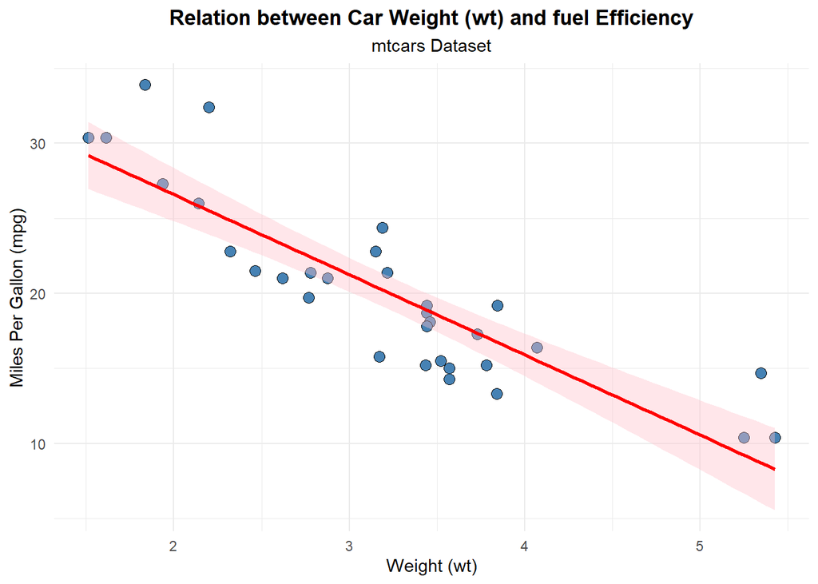

```r
ggplot(mtcars, aes(x=wt,y=mpg))+
  geom_point(
    size=3,
    shape=21,
    color="black",
    fill="steelblue"
  )+
  geom_smooth(
    method="lm",
    se=TRUE,
    color="Red",
    fill="Pink"
  )+
  labs(
    title="Relation between Car Weight (wt) and fuel Efficiency",
    subtitle="mtcars Dataset",
    x="Weight (wt)",
    y="Miles Per Gallon (mpg)"
  )+
    theme_minimal()+
    theme(
      plot.title=element_text(hjust=0.5,face="bold"),
      plot.subtitle=element_text(hjust=0.5)
    )
```